# Cointegration

Tyler J. Brough

12/3/2016

# Introduction: Cointegration Notes

These notes are based on material from several sources:

- Chapter 22 of Greene
- Chapter 19 of Kennedy
- Chapter 11 in Cochrane
- Chapter 8 in Brooks

# A Monte Carlo Study to Demonstrate Spurious Regression

## Spurious Regression

Consider the following two *independent* unit-root nonstationary processes:

$$\begin{align}
y_{1,t} &= y_{1,t-1} + u_{t} \\
y_{2,t} &= y_{2,t-1} + v_{t}
\end{align}$$

with $E(u_{t}, v_{s}) = 0$ for every $t,s$.

A regression on one of these series on the other, such as:

$$y_{1,t} = \alpha + \beta y_{2,t} + \varepsilon_{t}$$

*NB:* we expect the $t$-statistic to fail to reject the null $H_{0}: \beta = 0$, give their independence.

## Monte Carlo Simulation

But if either or both (as in this case!) of $y_{1,t}$ or $y_{2,t}$ is a unit-root process this regression violates the assumptions of the CLRM and will result in spurious results.

To illustrate this, consider the following Monte Carlo simulation:

1. Simulate an articifial dataset consisting of 500 observations from the processes given above.
2. Regress $y_{1,t}$ on $y_{2,t}$ and store the resulting $R^{2}$ and $t$-ratio.
3. Repeat this process for $i = 1, 2, \cdots, M$ with $M = 10,000$.
4. Plot histograms of the $M$ $R^{2}$’s and $t$-ratios.

## The R Code

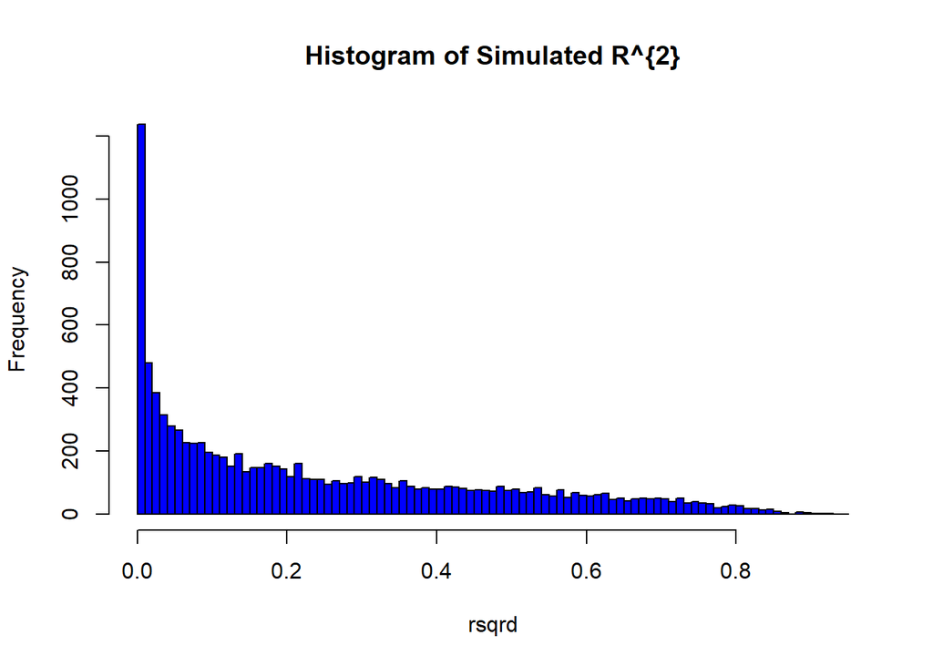

```r
M <- 10000
T <- 500

rsqrd <- rep(0, M)
tstat <- rep(0, M)

for(i in 1:M)
{
    y <- cumsum(rnorm(T))
    x <- cumsum(rnorm(T))
    fit <- lm(y ~ x)
    rsqrd[i] <- summary(fit)$r.squared
    tstat[i] <- summary(fit)$coefficients[2,3]
}

hist(rsqrd, breaks = 100, col="blue", main = "Histogram of Simulated R^{2}")
```

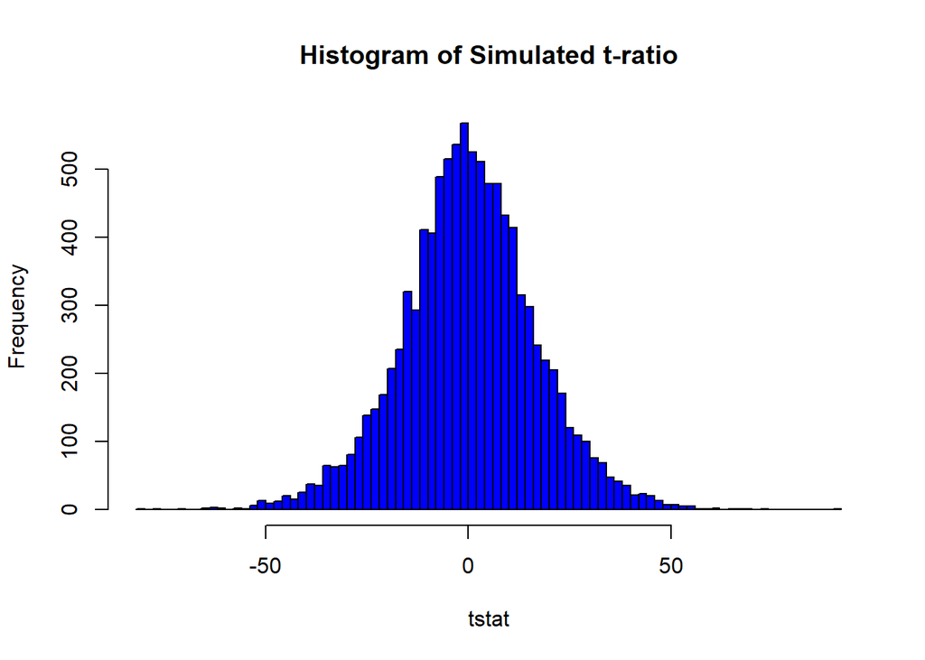

```r
hist(tstat, breaks = 100, col="blue", main = "Histogram of Simulated t-ratio")
```

## Cointegration $\phantom{Page 1 of ECN7320 Notes Dated 03/01/2011}$

Cointegration is a generalization of unit roots to vector systems.

**Definition:** Suppose that two time series are each integrated, i.e. have unit roots, and hence have the following moving average representations:

$$\begin{align}
(1 - L)y_{t} &= a(L)\delta_{t} \\
(1 - L)w_{t} &= b(L)v_{t}
\end{align}$$

## $\phantom{Page 2}$

In general linear combinations of $y$ and $w$ also have unit roots.

If however, there is some linear combination, say

$$y_{t} = \alpha w_{t}$$

that is stationary, $y_{t}$ and $w_{t}$ are said to be *cointegrated*, and $[1 - \alpha]$ is their *cointegrating vector*.

## Some Plausible Examples $\phantom{These plots and data inserted. Not in original notes.}$

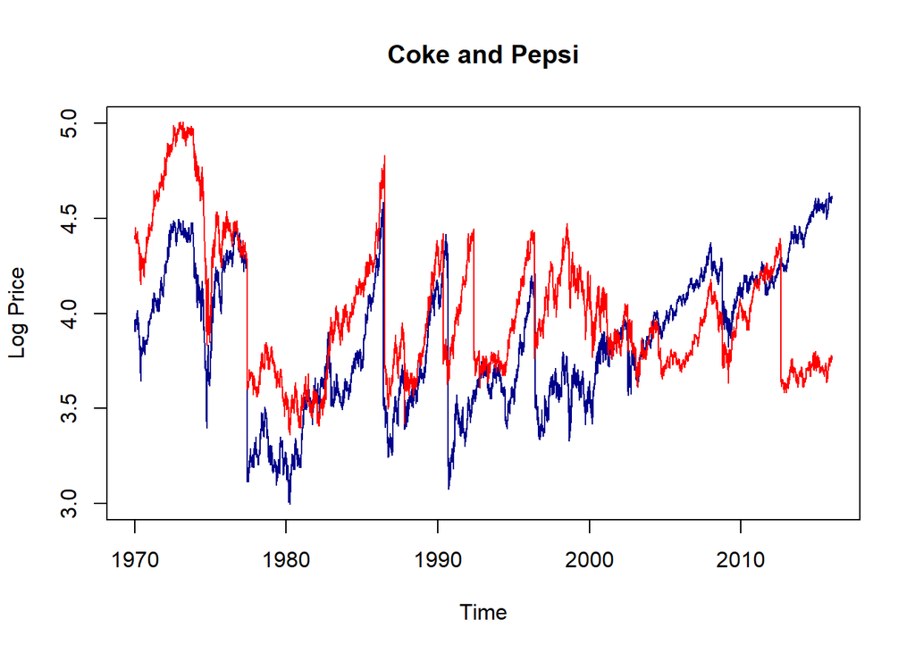

```r
library(xts)
rm(list=ls())

ko.raw <- read.csv("ko-1970-2015.csv", sep=",", header=T)
pep.raw <- read.csv("pep-1970-2015.csv", sep=",", header=T)

ko.dates <- as.Date(as.character(ko.raw$date), "%Y%m%d")
pep.dates <- as.Date(as.character(pep.raw$date), "%Y%m%d")

pep <- zoo(log(pep.raw$PRC), order.by = pep.dates)
ko <- zoo(log(ko.raw$PRC), order.by = ko.dates)
mts <- merge(pep, ko)

plot(mts, plot.type = "single", col=c("darkblue", "red"), xlab="Time", ylab="Log Price", main = "Coke and Pepsi")
```

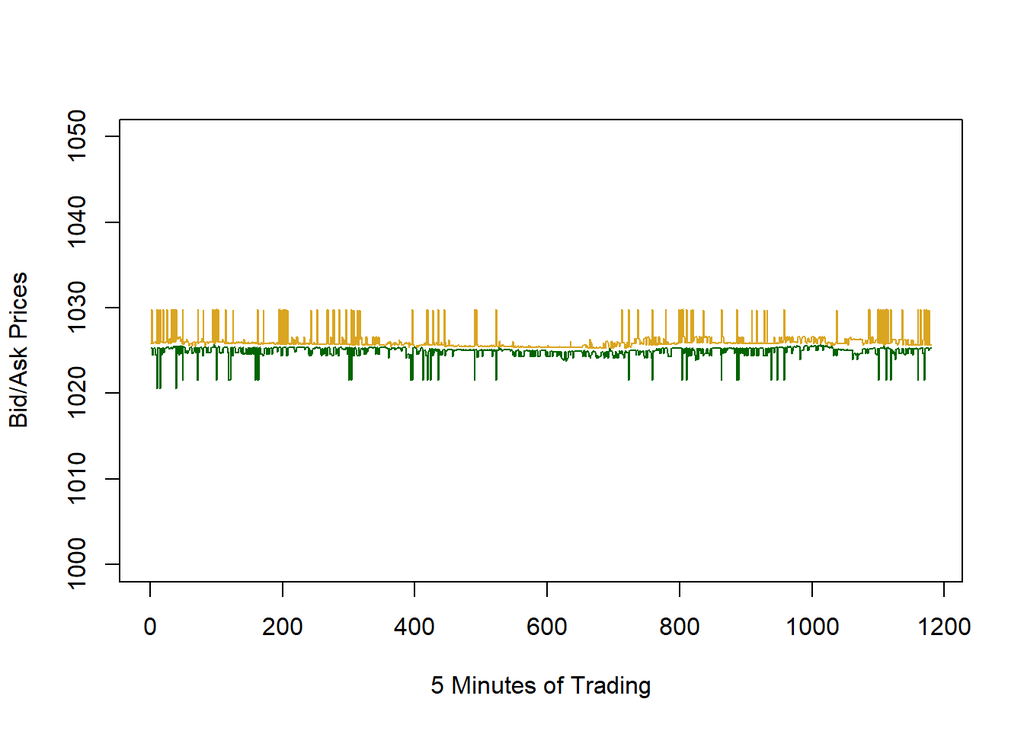

```r
library(xts)

raw <- read.csv("goog-bid-ask.csv", sep=",", header=T)
raw$SPRD <- raw$OFR - raw$BID
tmp <- raw[raw$BID > 0 & raw$OFR > 0, ]
tmp <- tmp[tmp$SPRD < 10, ]
mts <- merge(as.zoo(tmp$OFR), as.zoo(tmp$BID))
names(mts) <- c("ask", "bid")

plot(mts, ylim=c(1000, 1050), plot.type="single", xlab="5 Minutes of Trading", ylab="Bid/Ask Prices", col=c("goldenrod", "darkgreen"))
```